# Méthodes d’apprentissage non-supervisé

Daniel Pont

06/07/2020

# Méthodes d’apprentissage non-supervisé

## 1. Clustering

### 1.1 Distances

Distances courantes :

- Euclidienne
- Hamming (siatnce entre ‘101’ et ‘110’ = nbre digits différents = 2)
- Manhattan (city block : nbre de blocs horiz + nbre bloc vertic)
- Cosinus ( Produit scalaire / Produit des normes)

### 1.2 Préparation des données

```r
protein <- read.table("data/protein.txt", sep = "\t", header=TRUE)
summary(protein)
```

```
##            Country      RedMeat         WhiteMeat           Eggs
##  Albania       : 1   Min.   : 4.400   Min.   : 1.400   Min.   :0.500
##  Austria       : 1   1st Qu.: 7.800   1st Qu.: 4.900   1st Qu.:2.700
##  Belgium       : 1   Median : 9.500   Median : 7.800   Median :2.900
##  Bulgaria      : 1   Mean   : 9.828   Mean   : 7.896   Mean   :2.936
##  Czechoslovakia: 1   3rd Qu.:10.600   3rd Qu.:10.800   3rd Qu.:3.700
##  Denmark       : 1   Max.   :18.000   Max.   :14.000   Max.   :4.700
##  (Other)       :19
##       Milk            Fish           Cereals          Starch
##  Min.   : 4.90   Min.   : 0.200   Min.   :18.60   Min.   :0.600
##  1st Qu.:11.10   1st Qu.: 2.100   1st Qu.:24.30   1st Qu.:3.100
##  Median :17.60   Median : 3.400   Median :28.00   Median :4.700
##  Mean   :17.11   Mean   : 4.284   Mean   :32.25   Mean   :4.276
##  3rd Qu.:23.30   3rd Qu.: 5.800   3rd Qu.:40.10   3rd Qu.:5.700
##  Max.   :33.70   Max.   :14.200   Max.   :56.70   Max.   :6.500
##
##       Nuts           Fr.Veg
##  Min.   :0.700   Min.   :1.400
##  1st Qu.:1.500   1st Qu.:2.900
##  Median :2.400   Median :3.800
##  Mean   :3.072   Mean   :4.136
##  3rd Qu.:4.700   3rd Qu.:4.900
##  Max.   :7.800   Max.   :7.900
##
```

```r
# mise à l'échelle

vars_to_use <- colnames(protein)[-1]
pmatrix <- scale(protein[, vars_to_use])
pcenter <- attr(pmatrix, "scaled:center")
pscale <- attr(pmatrix, "scaled:scale")

#supprime les attributs de mise à l'échelle
rm_scales <- function(scaled_matrix) {
    attr(scaled_matrix, "scaled:center") <- NULL
    attr(scaled_matrix, "scaled:scale") <- NULL
    scaled_matrix
}

pmatrix <- rm_scales(pmatrix)
```

### 1.3 Clustering hiérarchique

#### 1.3.1 Création d’un dendrogramme avec hclust

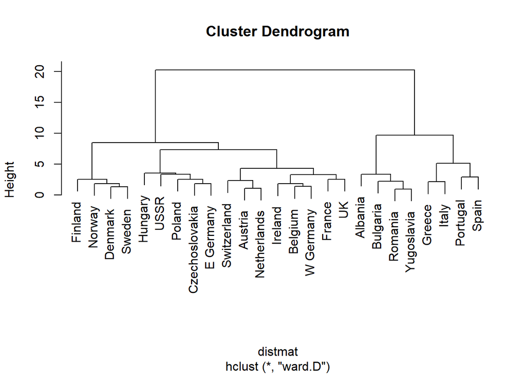

```r
distmat <- dist(pmatrix, method = "euclidean")
pfit <- hclust(distmat, method = "ward.D")
plot(pfit, labels = protein$Country)
```

```r
#Extraction  des membres de chaque cluster
groups <- cutree(pfit, k = 5)

print_clusters <- function(data, groups, columns) {
    groupedD <- split(data, groups)
    lapply(groupedD,
    function(df) df[, columns])
}

cols_to_print <- wrapr::qc(Country, RedMeat, Fish, Fr.Veg)
print_clusters(protein, groups, cols_to_print)
```

```
## $`1`
##       Country RedMeat Fish Fr.Veg
## 1     Albania    10.1  0.2    1.7
## 4    Bulgaria     7.8  1.2    4.2
## 18    Romania     6.2  1.0    2.8
## 25 Yugoslavia     4.4  0.6    3.2
##
## $`2`
##        Country RedMeat Fish Fr.Veg
## 2      Austria     8.9  2.1    4.3
## 3      Belgium    13.5  4.5    4.0
## 9       France    18.0  5.7    6.5
## 12     Ireland    13.9  2.2    2.9
## 14 Netherlands     9.5  2.5    3.7
## 21 Switzerland    13.1  2.3    4.9
## 22          UK    17.4  4.3    3.3
## 24   W Germany    11.4  3.4    3.8
##
## $`3`
##           Country RedMeat Fish Fr.Veg
## 5  Czechoslovakia     9.7  2.0    4.0
## 7       E Germany     8.4  5.4    3.6
## 11        Hungary     5.3  0.3    4.2
## 16         Poland     6.9  3.0    6.6
## 23           USSR     9.3  3.0    2.9
##
## $`4`
##    Country RedMeat Fish Fr.Veg
## 6  Denmark    10.6  9.9    2.4
## 8  Finland     9.5  5.8    1.4
## 15  Norway     9.4  9.7    2.7
## 20  Sweden     9.9  7.5    2.0
##
## $`5`
##     Country RedMeat Fish Fr.Veg
## 10   Greece    10.2  5.9    6.5
## 13    Italy     9.0  3.4    6.7
## 17 Portugal     6.2 14.2    7.9
## 19    Spain     7.1  7.0    7.2
```

#### 1.3.2 Projection des clusters sur les 2 principaux composants PCA :

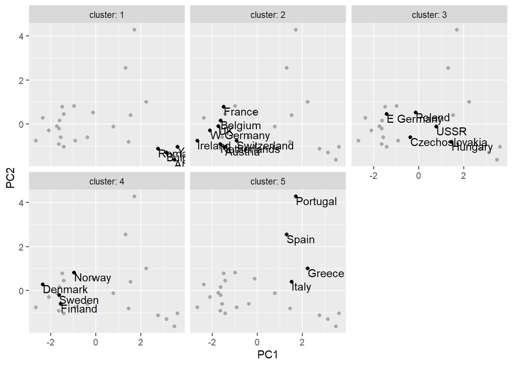

```r
library(ggplot2)

princ <- prcomp(pmatrix)
nComp <- 2

project <- predict(princ, pmatrix)[, 1:nComp]

project_plus <- cbind(as.data.frame(project),
                        cluster = as.factor(groups),
                        country = protein$Country)

ggplot(project_plus, aes(x = PC1, y = PC2)) +
        geom_point(data = as.data.frame(project), color = "darkgrey") +
        geom_point() +
        geom_text(aes(label = country),
        hjust = 0, vjust = 1) +
        facet_wrap(~ cluster, ncol = 3, labeller = label_both)
```

#### 1.3.3 Evaluation bootstrap des clusters - fpc::clusterboot

```r
library(fpc)

kbest_p <- 5
cboot_hclust <- clusterboot(pmatrix,
                    clustermethod = hclustCBI,
                    method = "ward.D",
                    k = kbest_p)
```

[output not shown]

[output cut: 45 more lines]

[output not shown]

```r
summary(cboot_hclust$result)
```

```
##               Length Class  Mode
## result         7     hclust list
## noise          1     -none- logical
## nc             1     -none- numeric
## clusterlist    5     -none- list
## partition     25     -none- numeric
## clustermethod  1     -none- character
## nccl           1     -none- numeric
```

```r
groups <- cboot_hclust$result$partition
print_clusters(protein, groups, cols_to_print)
```

```
## $`1`
##       Country RedMeat Fish Fr.Veg
## 1     Albania    10.1  0.2    1.7
## 4    Bulgaria     7.8  1.2    4.2
## 18    Romania     6.2  1.0    2.8
## 25 Yugoslavia     4.4  0.6    3.2
##
## $`2`
##        Country RedMeat Fish Fr.Veg
## 2      Austria     8.9  2.1    4.3
## 3      Belgium    13.5  4.5    4.0
## 9       France    18.0  5.7    6.5
## 12     Ireland    13.9  2.2    2.9
## 14 Netherlands     9.5  2.5    3.7
## 21 Switzerland    13.1  2.3    4.9
## 22          UK    17.4  4.3    3.3
## 24   W Germany    11.4  3.4    3.8
##
## $`3`
##           Country RedMeat Fish Fr.Veg
## 5  Czechoslovakia     9.7  2.0    4.0
## 7       E Germany     8.4  5.4    3.6
## 11        Hungary     5.3  0.3    4.2
## 16         Poland     6.9  3.0    6.6
## 23           USSR     9.3  3.0    2.9
##
## $`4`
##    Country RedMeat Fish Fr.Veg
## 6  Denmark    10.6  9.9    2.4
## 8  Finland     9.5  5.8    1.4
## 15  Norway     9.4  9.7    2.7
## 20  Sweden     9.9  7.5    2.0
##
## $`5`
##     Country RedMeat Fish Fr.Veg
## 10   Greece    10.2  5.9    6.5
## 13    Italy     9.0  3.4    6.7
## 17 Portugal     6.2 14.2    7.9
## 19    Spain     7.1  7.0    7.2
```

```r
# Vector indiquant la stabilité des clusters
cboot_hclust$bootmean
```

```
## [1] 0.8266667 0.7600992 0.6104048 0.8594325 0.7358333
```

```r
# Le nombre de fois où chaque cluster a disparu (par défaut clusterboot() a 100 itérations)
cboot_hclust$bootbrd
```

```
## [1] 19 21 49 18 34
```

#### 1.3.4 Détermination du nombre de clusters

Une 1ère solution est de calculer le total des **within sum of squares (WSS)** de chque cluster pour différentes valeurs de k et de chercher un coude dans la courbe.

```r
sqr_edist <- function(x, y) {
    sum((x - y)^2)
}

# Fonction pour calculer le WSS d'un cluster
wss_cluster <- function(clustermat) {
    # centre du cluster
    c0 <- colMeans(clustermat)
    # calcule la distance au carré entre chaque point du cluster et le centre
    # calcule la somme  de ces distances au carré
    sum(apply(clustermat, 1, FUN = function(row) { sqr_edist(row, c0) }))
}

wss_total <- function(dmatrix, labels) {
    wsstot <- 0
    k <- length(unique(labels))
    for(i in 1:k)
        wsstot <- wsstot + wss_cluster(subset(dmatrix, labels == i))
    wsstot
}

# calcule la somme de tous les WSS
wss_total(pmatrix, groups)
```

```
## [1] 71.94342
```

Représentation graphique des WSS pour différentes valeurs de k :

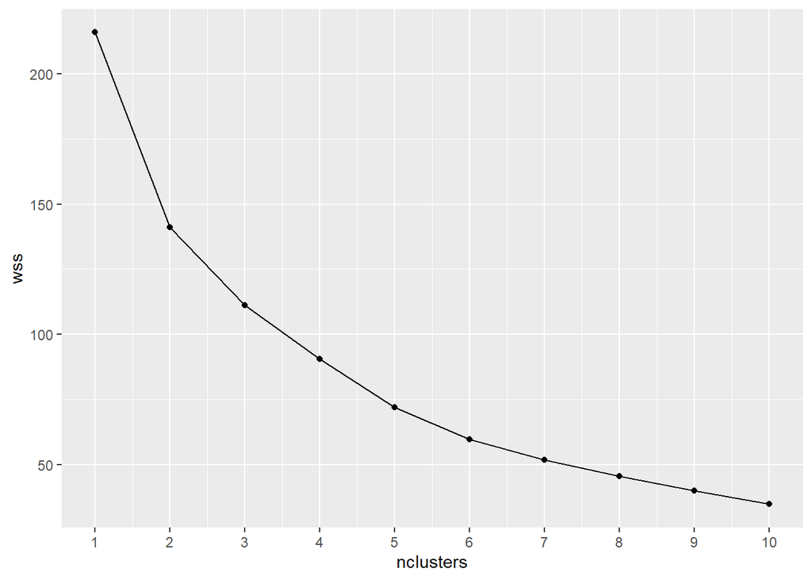

```r
get_wss <- function(dmatrix, max_clusters) {
    wss = numeric(max_clusters)

    #wss de toutes les données (1 seul cluster)
    wss[1] <- wss_cluster(dmatrix)

    d <- dist(dmatrix, method = "euclidean")

    # clusterise les données
    pfit <- hclust(d, method = "ward.D")

    for(k in 2:max_clusters) {
        labels <- cutree(pfit, k = k)
        wss[k] <- wss_total(dmatrix, labels)
    }

    wss
}

kmax <- 10
cluster_meas <- data.frame(nclusters = 1:kmax,
                    wss = get_wss(pmatrix, kmax))

breaks <- 1:kmax
ggplot(cluster_meas, aes(x=nclusters, y = wss)) +
    geom_point() + geom_line() +
    scale_x_continuous(breaks = breaks)
```

Il n’y a pas de coude net, les valeurs k=2,5 et 6 sont plausibles.

**Calinski-Harabasz index**

L’indice de Calinski-Harabasz est une autre mesure couramment utilisée de la qualité des Clusters. Pour motiver (et calculer) l’indice de Calinski-Harabasz (indice CH, pour faire court), nous devons d’abord définir quelques termes supplémentaires.

- **TSS (Total Sum of Square)** d’un ensemble de points est la somme des distances au carré de tous les points du centre de gravité des données (WSS pour 1 seul cluster)
- **BSS (between sum of squares)** = TSS - WSS

Représentation graphique des BSS et WSS pour différentes valeurs de k :

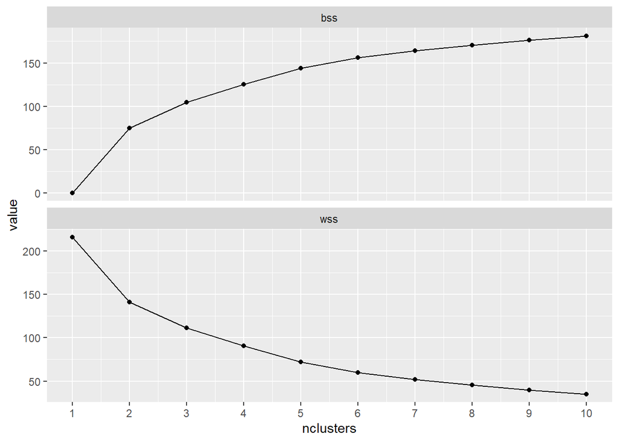

```r
total_ss <- function(dmatrix) {
    grandmean <- colMeans(dmatrix)
    sum(apply(dmatrix, 1, FUN = function(row) { sqr_edist(row, grandmean) }))
}

tss <- total_ss(pmatrix)
cluster_meas$bss <- with(cluster_meas, tss - wss)

library(cdata)
cmlong <- unpivot_to_blocks(cluster_meas,
                            nameForNewKeyColumn = "measure",
                            nameForNewValueColumn = "value",
                            columnsToTakeFrom = c("wss", "bss"))

ggplot(cmlong, aes(x = nclusters, y = value)) +
        geom_point() + geom_line() +
        facet_wrap(~measure, ncol = 1, scale = "free_y") +
        scale_x_continuous(breaks = 1:10)
```

- within cluster variance W = WSS / (n - k)
- between cluster variance B = BSS / (k - 1)
- **Calinski-Harabasz (CH) index** = B/W

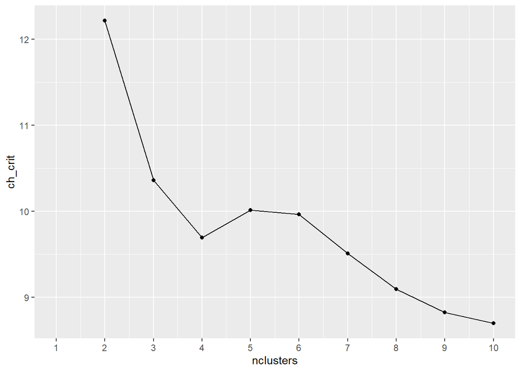

```r
cluster_meas$B <- with(cluster_meas, bss / (nclusters - 1))
n = nrow(pmatrix)
cluster_meas$W <- with(cluster_meas, wss / (n - nclusters))

# Calcul du CH
cluster_meas$ch_crit <- with(cluster_meas, B / W)

# Représentation graphique du CH
ggplot(cluster_meas, aes(x = nclusters, y = ch_crit)) +
        geom_point() + geom_line() +
        scale_x_continuous(breaks = 1:kmax)
```

### 1.4 K-means

#### 1.4.1 Exécution de K-means

```r
kbest_p <- 5
pclusters <- kmeans(pmatrix, kbest_p, nstart = 100, iter.max = 100)
summary(pclusters)
```

```
##              Length Class  Mode
## cluster      25     -none- numeric
## centers      45     -none- numeric
## totss         1     -none- numeric
## withinss      5     -none- numeric
## tot.withinss  1     -none- numeric
## betweenss     1     -none- numeric
## size          5     -none- numeric
## iter          1     -none- numeric
## ifault        1     -none- numeric
```

```r
pclusters$centers
```

```
##        RedMeat  WhiteMeat        Eggs       Milk       Fish    Cereals
## 1 -0.807569986 -0.8719354 -1.55330561 -1.0783324 -1.0386379  1.7200335
## 2  1.011180399  0.7421332  0.94084150  0.5700581 -0.2671539 -0.6877583
## 3  0.006572897 -0.2290150  0.19147892  1.3458748  1.1582546 -0.8722721
## 4 -0.570049402  0.5803879 -0.08589708 -0.4604938 -0.4537795  0.3181839
## 5 -0.508801956 -1.1088009 -0.41248496 -0.8320414  0.9819154  0.1300253
##       Starch       Nuts      Fr.Veg
## 1 -1.4234267  0.9961313 -0.64360439
## 2  0.2288743 -0.5083895  0.02161979
## 3  0.1676780 -0.9553392 -1.11480485
## 4  0.7857609 -0.2679180  0.06873983
## 5 -0.1842010  1.3108846  1.62924487
```

```r
pclusters$size
```

```
## [1] 4 8 4 5 4
```

```r
groups <- pclusters$cluster
cols_to_print = wrapr::qc(Country, RedMeat, Fish, Fr.Veg)
print_clusters(protein, groups, cols_to_print)
```

```
## $`1`
##       Country RedMeat Fish Fr.Veg
## 1     Albania    10.1  0.2    1.7
## 4    Bulgaria     7.8  1.2    4.2
## 18    Romania     6.2  1.0    2.8
## 25 Yugoslavia     4.4  0.6    3.2
##
## $`2`
##        Country RedMeat Fish Fr.Veg
## 2      Austria     8.9  2.1    4.3
## 3      Belgium    13.5  4.5    4.0
## 9       France    18.0  5.7    6.5
## 12     Ireland    13.9  2.2    2.9
## 14 Netherlands     9.5  2.5    3.7
## 21 Switzerland    13.1  2.3    4.9
## 22          UK    17.4  4.3    3.3
## 24   W Germany    11.4  3.4    3.8
##
## $`3`
##    Country RedMeat Fish Fr.Veg
## 6  Denmark    10.6  9.9    2.4
## 8  Finland     9.5  5.8    1.4
## 15  Norway     9.4  9.7    2.7
## 20  Sweden     9.9  7.5    2.0
##
## $`4`
##           Country RedMeat Fish Fr.Veg
## 5  Czechoslovakia     9.7  2.0    4.0
## 7       E Germany     8.4  5.4    3.6
## 11        Hungary     5.3  0.3    4.2
## 16         Poland     6.9  3.0    6.6
## 23           USSR     9.3  3.0    2.9
##
## $`5`
##     Country RedMeat Fish Fr.Veg
## 10   Greece    10.2  5.9    6.5
## 13    Italy     9.0  3.4    6.7
## 17 Portugal     6.2 14.2    7.9
## 19    Spain     7.1  7.0    7.2
```

#### 1.4.2 Détermination de K avec kmeansruns()

```r
clustering_ch <- kmeansruns(pmatrix, krange = 1:10, criterion = "ch")
clustering_ch$bestk
```

```
## [1] 2
```

```r
#asw = average silhoute weight
clustering_asw <- kmeansruns(pmatrix, krange = 1:10, criterion = "asw")
clustering_asw$bestk
```

```
## [1] 3
```

```r
clustering_asw$crit
```

```
##  [1] 0.0000000 0.3271084 0.3351694 0.2617868 0.2639450 0.2734815 0.2471165
##  [8] 0.2429985 0.2412922 0.2388293
```

```r
clustering_ch$crit
```

```
##  [1]  0.000000 14.094814 11.417985 10.418801 10.011797  9.964967  9.861682
##  [8]  9.412089  9.166676  9.075569
```

```r
cluster_meas$ch_crit
```

```
##  [1]       NaN 12.215107 10.359587  9.690891 10.011797  9.964967  9.506978
##  [8]  9.092065  8.822406  8.695065
```

```r
summary(clustering_ch)
```

```
##              Length Class  Mode
## cluster      25     -none- numeric
## centers      18     -none- numeric
## totss         1     -none- numeric
## withinss      2     -none- numeric
## tot.withinss  1     -none- numeric
## betweenss     1     -none- numeric
## size          2     -none- numeric
## iter          1     -none- numeric
## ifault        1     -none- numeric
## crit         10     -none- numeric
## bestk         1     -none- numeric
```

#### 1.4.3 Utilisation de clusterboot() avec k-means

```r
kbest_p <- 5
cboot <- clusterboot(pmatrix, clustermethod = kmeansCBI,
                      runs = 100,iter.max = 100,
                      krange = kbest_p, seed = 15555)
```

[output not shown]

[output cut: 45 more lines]

[output not shown]

```r
groups <- cboot$result$partition

print_clusters(protein, groups, cols_to_print)
```

```
## $`1`
##     Country RedMeat Fish Fr.Veg
## 10   Greece    10.2  5.9    6.5
## 13    Italy     9.0  3.4    6.7
## 17 Portugal     6.2 14.2    7.9
## 19    Spain     7.1  7.0    7.2
##
## $`2`
##        Country RedMeat Fish Fr.Veg
## 2      Austria     8.9  2.1    4.3
## 3      Belgium    13.5  4.5    4.0
## 9       France    18.0  5.7    6.5
## 12     Ireland    13.9  2.2    2.9
## 14 Netherlands     9.5  2.5    3.7
## 21 Switzerland    13.1  2.3    4.9
## 22          UK    17.4  4.3    3.3
## 24   W Germany    11.4  3.4    3.8
##
## $`3`
##           Country RedMeat Fish Fr.Veg
## 5  Czechoslovakia     9.7  2.0    4.0
## 7       E Germany     8.4  5.4    3.6
## 11        Hungary     5.3  0.3    4.2
## 16         Poland     6.9  3.0    6.6
## 23           USSR     9.3  3.0    2.9
##
## $`4`
##    Country RedMeat Fish Fr.Veg
## 6  Denmark    10.6  9.9    2.4
## 8  Finland     9.5  5.8    1.4
## 15  Norway     9.4  9.7    2.7
## 20  Sweden     9.9  7.5    2.0
##
## $`5`
##       Country RedMeat Fish Fr.Veg
## 1     Albania    10.1  0.2    1.7
## 4    Bulgaria     7.8  1.2    4.2
## 18    Romania     6.2  1.0    2.8
## 25 Yugoslavia     4.4  0.6    3.2
```

### 1.5 Assignation de nouveaux points aux clusters

#### 1.5.1 Fonction permettant d’assigner des points à un cluster

```r
assign_cluster <- function(newpt, centers, xcenter = 0, xscale = 1) {
                      xpt <- (newpt - xcenter) / xscale
                      dists <- apply(centers, 1, FUN = function(c0) { sqr_edist(c0, xpt) })
                      which.min(dists)
                  }
```

#### 1.5.2 Génération artificielle de clusters

```r
mean1 <- c(1, 1, 1)
sd1 <- c(1, 2, 1)
mean2 <- c(10, -3, 5)
sd2 <- c(2, 1, 2)
mean3 <- c(-5, -5, -5)
sd3 <- c(1.5, 2, 1)

library(MASS)
clust1 <- mvrnorm(100, mu = mean1, Sigma = diag(sd1))
clust2 <- mvrnorm(100, mu = mean2, Sigma = diag(sd2))
clust3 <- mvrnorm(100, mu = mean3, Sigma = diag(sd3))

toydata <- rbind(clust3, rbind(clust1, clust2))
tmatrix <- scale(toydata)
tcenter <- attr(tmatrix, "scaled:center")
tscale <-attr(tmatrix, "scaled:scale")
tmatrix <- rm_scales(tmatrix)

kbest_t <- 3
tclusters <- kmeans(tmatrix, kbest_t, nstart = 100, iter.max = 100)
tclusters$size
```

```
## [1] 100  99 101
```

#### 1.5.3 Restitution des centres à l’état avant la mise à l’échelle

```r
unscaled = scale(tclusters$centers, center = FALSE, scale = 1 / tscale)
rm_scales(scale(unscaled, center = -tcenter, scale = FALSE))
```

```
##         [,1]       [,2]       [,3]
## 1 -4.7554083 -5.0841602 -5.0110629
## 2  9.9278210 -2.9398534  4.8330536
## 3  0.9833241  0.7977014  0.8149083
```

#### Exemple d’assignation de points aux clusters

```r
assign_cluster(mvrnorm(1, mean1, diag(sd1)),
          tclusters$centers,
          tcenter, tscale)
```

```
## 3
## 3
```

```r
assign_cluster(mvrnorm(1, mean2, diag(sd2)),
          tclusters$centers,
          tcenter, tscale)
```

```
## 2
## 2
```

```r
assign_cluster(mvrnorm(1, mean3, diag(sd3)),
          tclusters$centers,
          tcenter, tscale)
```

```
## 1
## 1
```

## 2. Règles d’association

### 2.1 Introduction

Les règles d’association sont utilisée pour rechercher des objets ou des attributs qui apparaissent fréquemment ensemble, par exemple, des produits qui sont souvent achetés simultanemént lors d’une session de shopping ou des requêtes qui ont tendance à être exécutées dans une même session sur le moteur de recherche d’un site Web. Ces informations peuvent être utilisées pour recommander des produits aux acheteurs, pour regrouper les articles fréquemment regroupés sur les étagères des magasins ou pour repenser les sites Web pour une navigation plus facile.

Les éléments clés sont les suivants :

- **Règles**

La règle «si X, alors Y» signifie que chaque fois que vous voyez l’ensemble d’éléments X dans une transaction, vous vous attendez à voir également Y (avec une confiance donnée). Pour l’algorithme apriori (que nous verrons dans cette section), Y est toujours un ensemble avec un seul élément.

- **Support** :

Supposons que votre base de données de transactions s’appelle T et X est un ensemble d’éléments. Le support (X) est le nombre de transactions qui contiennent X divisé par le nombre total de transactions dans T.

- **Indice de Confiance** :

La confiance d’une régle est définit par la proportion de transactions de T contenat X qui contiennent aussi Y.. Le but de l’exploration de règles d’association est de trouver toutes les règles intéressantes dans la base de données avec au moins un support minimum donné (disons, 10%) et une confiance donnée minimum (disons, 60%)

### 2.2 Exemple

Supposons que vous travailliez pour une librairie et que vous souhaitiez recommander des livres qui pourraient intéresser un client, en fonction de tous ses achats et des livres précédemment consultés. Vous souhaitez utiliser les informations de l’historique pour développer des règles de recommandation.

### 2.3 Utilisation du package arules

#### 2.3.1 Lecture des données

```r
library(arules)
bookbaskets <- read.transactions("data/bookdata.tsv.gz",
                  format = "single",
                  header = TRUE,
                  sep = "\t",
                  cols = c("userid", "title"),
                  rm.duplicates = TRUE)
```

NB : cols spécifie respectivement les colonnes *id de transaction* et *id d’élement*

#### 2.3.2 Exploration des données

Données de transaction:

```r
class(bookbaskets)
```

```
## [1] "transactions"
## attr(,"package")
## [1] "arules"
```

```r
bookbaskets
```

```
## transactions in sparse format with
##  92108 transactions (rows) and
##  220447 items (columns)
```

```r
dim(bookbaskets)
```

```
## [1]  92108 220447
```

```r
# titre des livres
colnames(bookbaskets)[1:5]
```

```
## [1] "''N'' Is for Noose"
## [2] "' Allo 'Allo: the War Diaries of Rene Artois"
## [3] "' Boule De Suif"
## [4] "' Civil Disobedience' and 'Reading'"
## [5] "' How to Travel with a Salmon and Other Essays"
```

```r
# id des clients
rownames(bookbaskets)[1:5]
```

```
## [1] "10"     "1000"   "100001" "100002" "100004"
```

```r
basketSizes <- size(bookbaskets)
summary(basketSizes)
```

```
##    Min. 1st Qu.  Median    Mean 3rd Qu.    Max.
##     1.0     1.0     1.0    11.1     4.0 10253.0
```

Distribution de la taille des paniers :

```r
library(ggplot2)

quantile(basketSizes, probs = seq(0, 1, 0.1))
```

```
##    0%   10%   20%   30%   40%   50%   60%   70%   80%   90%  100%
##     1     1     1     1     1     1     2     3     5    13 10253
```

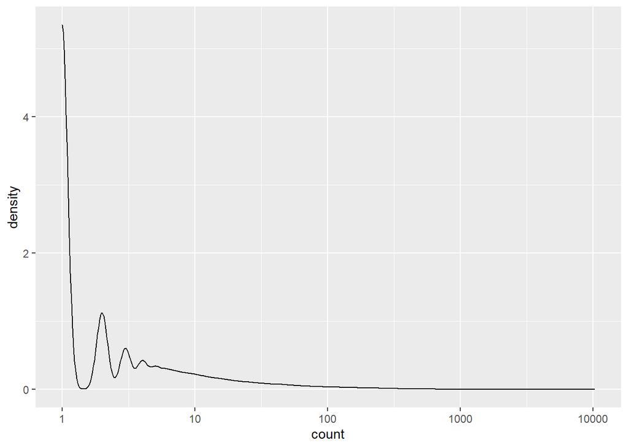

```r
ggplot(data.frame(count = basketSizes)) +
        geom_density(aes(x = count)) +
        scale_x_log10()
```

Fréquence d’apparition des livres :

```r
bookCount <- itemFrequency(bookbaskets, "absolute")
summary(bookCount)
```

```
##     Min.  1st Qu.   Median     Mean  3rd Qu.     Max.
##    1.000    1.000    1.000    4.638    3.000 2502.000
```

10 livres les plus fréquents :

```r
orderedBooks <- sort(bookCount, decreasing = TRUE)
knitr::kable(orderedBooks[1:10])
```

|  | x |
| --- | --- |
| Wild Animus | 2502 |
| The Lovely Bones: A Novel | 1295 |
| She’s Come Undone | 934 |
| The Da Vinci Code | 905 |
| Harry Potter and the Sorcerer’s Stone | 832 |
| The Nanny Diaries: A Novel | 821 |
| A Painted House | 819 |
| Bridget Jones’s Diary | 772 |
| The Secret Life of Bees | 762 |
| Divine Secrets of the Ya-Ya Sisterhood: A Novel | 737 |

```r
#Fréquence d'apparition dans les paniers du livre le plus populaire
orderedBooks[1] / nrow(bookbaskets)
```

```
## Wild Animus
##  0.02716376
```

Clients ayant mis dans leur panier au moins 2 livres :

```r
bookbaskets_use <- bookbaskets[basketSizes > 1]
dim(bookbaskets_use)
```

```
## [1]  40822 220447
```

Utilisation de la fonction apriori() :

```r
rules <- apriori(bookbaskets_use,
                  parameter = list(support = 0.002, confidence = 0.75))
```

```
## Apriori
##
## Parameter specification:
##  confidence minval smax arem  aval originalSupport maxtime support minlen
##        0.75    0.1    1 none FALSE            TRUE       5   0.002      1
##  maxlen target  ext
##      10  rules TRUE
##
## Algorithmic control:
##  filter tree heap memopt load sort verbose
##     0.1 TRUE TRUE  FALSE TRUE    2    TRUE
##
## Absolute minimum support count: 81
##
## set item appearances ...[0 item(s)] done [0.00s].
## set transactions ...[216031 item(s), 40822 transaction(s)] done [1.95s].
## sorting and recoding items ... [1256 item(s)] done [0.04s].
## creating transaction tree ... done [0.02s].
## checking subsets of size 1 2 3 4 5 done [0.07s].
## writing ... [191 rule(s)] done [0.00s].
## creating S4 object  ... done [0.04s].
```

```r
summary(rules)
```

```
## set of 191 rules
##
## rule length distribution (lhs + rhs):sizes
##   2   3   4   5
##  11 100  66  14
##
##    Min. 1st Qu.  Median    Mean 3rd Qu.    Max.
##   2.000   3.000   3.000   3.435   4.000   5.000
##
## summary of quality measures:
##     support           confidence        coverage             lift
##  Min.   :0.002009   Min.   :0.7500   Min.   :0.002082   Min.   : 40.89
##  1st Qu.:0.002131   1st Qu.:0.8113   1st Qu.:0.002511   1st Qu.: 86.44
##  Median :0.002278   Median :0.8468   Median :0.002719   Median :131.36
##  Mean   :0.002593   Mean   :0.8569   Mean   :0.003039   Mean   :129.68
##  3rd Qu.:0.002695   3rd Qu.:0.9065   3rd Qu.:0.003160   3rd Qu.:158.77
##  Max.   :0.005830   Max.   :0.9882   Max.   :0.006982   Max.   :321.89
##      count
##  Min.   : 82.0
##  1st Qu.: 87.0
##  Median : 93.0
##  Mean   :105.8
##  3rd Qu.:110.0
##  Max.   :238.0
##
## mining info:
##             data ntransactions support confidence
##  bookbaskets_use         40822   0.002       0.75
```

Inspection et evaluation des règles :

```r
measures <- interestMeasure(rules,
                  measure=c("coverage", "fishersExactTest"),
                  transactions = bookbaskets_use)
summary(measures)
```

```
##     coverage        fishersExactTest
##  Min.   :0.002082   Min.   : 0.000e+00
##  1st Qu.:0.002511   1st Qu.: 0.000e+00
##  Median :0.002719   Median : 0.000e+00
##  Mean   :0.003039   Mean   :5.080e-138
##  3rd Qu.:0.003160   3rd Qu.: 0.000e+00
##  Max.   :0.006982   Max.   :9.702e-136
```

Récupération des 5 règles avec le niveau de confiance le plus élevé :

```r
library(magrittr)

rules %>%
    sort(., by = "confidence") %>%
    head(., n = 5) %>%
    inspect(.)
```

```
##     lhs                                               rhs                                                support confidence    coverage      lift count
## [1] {Four to Score,
##      High Five,
##      Seven Up,
##      Two for the Dough}                            => {Three To Get Deadly : A Stephanie Plum Novel} 0.002057714  0.9882353 0.002082211 165.33500    84
## [2] {Harry Potter and the Order of the Phoenix,
##      Harry Potter and the Prisoner of Azkaban,
##      Harry Potter and the Sorcerer's Stone}        => {Harry Potter and the Chamber of Secrets}      0.002866102  0.9669421 0.002964088  72.82751   117
## [3] {Four to Score,
##      High Five,
##      One for the Money,
##      Two for the Dough}                            => {Three To Get Deadly : A Stephanie Plum Novel} 0.002082211  0.9659091 0.002155700 161.59976    85
## [4] {Four to Score,
##      Seven Up,
##      Three To Get Deadly : A Stephanie Plum Novel,
##      Two for the Dough}                            => {High Five}                                    0.002057714  0.9655172 0.002131204 180.79975    84
## [5] {High Five,
##      Seven Up,
##      Three To Get Deadly : A Stephanie Plum Novel,
##      Two for the Dough}                            => {Four to Score}                                0.002057714  0.9655172 0.002131204 167.72062    84
```

Elaboration de règles avec des restrictions :

```r
# par défaut tous les livres peuvent se trouver dans la partie gauche (lhs) de la règle
# seul "The Lovely Bones" peut apparaître dans la partie droite (rhs)
brules <- apriori(bookbaskets_use,
parameter = list(support = 0.001,
                confidence = 0.6),
                appearance = list(rhs = c("The Lovely Bones: A Novel"),
                default = "lhs"))
```

```
## Apriori
##
## Parameter specification:
##  confidence minval smax arem  aval originalSupport maxtime support minlen
##         0.6    0.1    1 none FALSE            TRUE       5   0.001      1
##  maxlen target  ext
##      10  rules TRUE
##
## Algorithmic control:
##  filter tree heap memopt load sort verbose
##     0.1 TRUE TRUE  FALSE TRUE    2    TRUE
##
## Absolute minimum support count: 40
##
## set item appearances ...[1 item(s)] done [0.00s].
## set transactions ...[216031 item(s), 40822 transaction(s)] done [1.31s].
## sorting and recoding items ... [3172 item(s)] done [0.04s].
## creating transaction tree ... done [0.02s].
## checking subsets of size 1 2 3 4 5 6 7 8 done [0.27s].
## writing ... [46 rule(s)] done [0.04s].
## creating S4 object  ... done [0.04s].
```

```r
summary(brules)
```

```
## set of 46 rules
##
## rule length distribution (lhs + rhs):sizes
##  3  4
## 44  2
##
##    Min. 1st Qu.  Median    Mean 3rd Qu.    Max.
##   3.000   3.000   3.000   3.043   3.000   4.000
##
## summary of quality measures:
##     support           confidence        coverage             lift
##  Min.   :0.001004   Min.   :0.6000   Min.   :0.001347   Min.   :21.81
##  1st Qu.:0.001029   1st Qu.:0.6118   1st Qu.:0.001647   1st Qu.:22.24
##  Median :0.001102   Median :0.6258   Median :0.001739   Median :22.75
##  Mean   :0.001132   Mean   :0.6365   Mean   :0.001786   Mean   :23.14
##  3rd Qu.:0.001219   3rd Qu.:0.6457   3rd Qu.:0.001917   3rd Qu.:23.47
##  Max.   :0.001396   Max.   :0.7455   Max.   :0.002278   Max.   :27.10
##      count
##  Min.   :41.00
##  1st Qu.:42.00
##  Median :45.00
##  Mean   :46.22
##  3rd Qu.:49.75
##  Max.   :57.00
##
## mining info:
##             data ntransactions support confidence
##  bookbaskets_use         40822   0.001        0.6
```

Inspection des règes :

```r
brules %>%
    sort(., by = "confidence") %>%
    lhs(.) %>%
    head(., n = 5) %>%
    inspect(.)
```

```
##     items
## [1] {Divine Secrets of the Ya-Ya Sisterhood: A Novel,
##      Lucky : A Memoir}
## [2] {Lucky : A Memoir,
##      The Notebook}
## [3] {Lucky : A Memoir,
##      Wild Animus}
## [4] {Midwives: A Novel,
##      Wicked: The Life and Times of the Wicked Witch of the West}
## [5] {Lucky : A Memoir,
##      Summer Sisters}
```

Inspection des règes avec restrictions :

```r
brulesSub <- subset(brules, subset = !(lhs %in% "Lucky : A Memoir"))

brulesSub %>%
        sort(., by = "confidence") %>%
        lhs(.) %>%
        head(., n = 5) %>%
        inspect(.)
```

```
##     items
## [1] {Midwives: A Novel,
##      Wicked: The Life and Times of the Wicked Witch of the West}
## [2] {She's Come Undone,
##      The Secret Life of Bees,
##      Wild Animus}
## [3] {A Walk to Remember,
##      The Nanny Diaries: A Novel}
## [4] {Beloved,
##      The Red Tent}
## [5] {The Da Vinci Code,
##      The Reader}
```

```r
brulesConf <- sort(brulesSub, by="confidence")

inspect(head(lhs(brulesConf), n = 5))
```

```
##     items
## [1] {Midwives: A Novel,
##      Wicked: The Life and Times of the Wicked Witch of the West}
## [2] {She's Come Undone,
##      The Secret Life of Bees,
##      Wild Animus}
## [3] {A Walk to Remember,
##      The Nanny Diaries: A Novel}
## [4] {Beloved,
##      The Red Tent}
## [5] {The Da Vinci Code,
##      The Reader}
```